# Reproducible Research: Peer Assessment 1

#### Loading and preprocessing the data

Loading the library ggplot2 we have used to draw the plots

```r
library(ggplot2)
dades <- read.csv("activity.csv")
dadesNetes <- na.omit(dades)
dadesPerDay <- dadesNetes[,1:2]
```

#### What is mean total number of steps taken per day?

We first calculate the total number of steps taken per day

```r
totalSteps <- aggregate(steps ~ date, dadesPerDay, FUN = sum)
```

The total number of steps taken per day are shown in the following plot

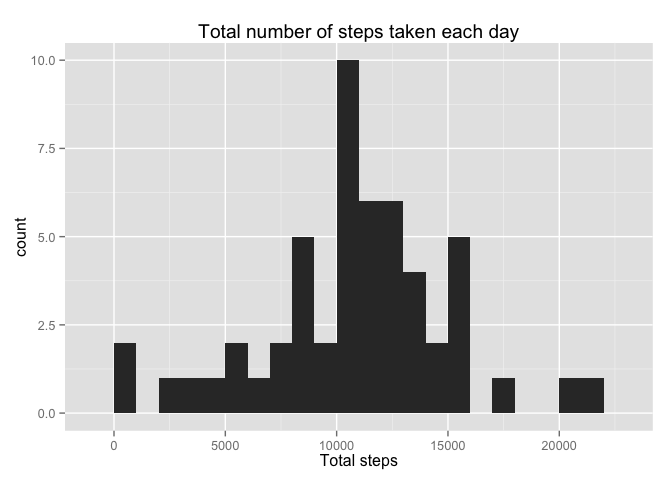

```r
ggplot(totalSteps, aes(x=steps)) + geom_histogram(binwidth=1000) +
    ggtitle("Total number of steps taken each day") +  xlab("Total steps")
```

What is mean total number of steps taken per day?

```r
options("scipen"=100)
meanSteps <- round(mean(totalSteps$steps), digits=2)
medianSteps <- median(totalSteps$steps)
```

The mean and median of the total number of steps taken per day are:  
- mean: 10766.19  
- median: 10765

#### What is the average daily activity pattern?

Make a time series plot of the 5-minute interval (x-axis) and the average number of steps taken, averaged across all days (y-axis).

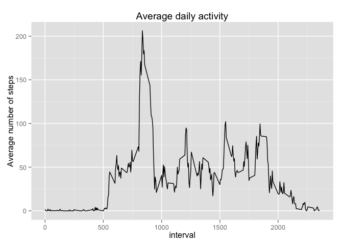

```r
dadesInterval <- dadesNetes[,c("steps", "interval")]
totalSteps <- aggregate( steps  ~ interval , data=dadesInterval, FUN = mean)

myplot <- qplot(interval, steps, data=totalSteps, geom="line", main="Average daily activity", ylab="Average number of steps")
print(myplot)
```

```r
maxInterval <- subset(totalSteps, totalSteps[,"steps"] == max(totalSteps$steps))$interval
maxIntervalTime <- format(strptime(sprintf("%04d", maxInterval), format="%H%M"), format="%H:%M")
```

The 5-minute interval, on average across all the days in the dataset, containing the maximum number of steps is 835 corresponding to 08:35

#### Imputing missing values

I have filled all of the missing values in the dataset assigning mean for that 5-minute interval.

```r
meanStepsInterval <- totalSteps
# I create a new column "stepsMean" to the dataset to store the mean of the 5-minute interval of each row
names(meanStepsInterval)[names(meanStepsInterval)=="steps"] <- "stepsMean"

# Adding in the new columm "stepsMean" the value of the mean of the 5-minute interval for each row
totesDades <- merge(dades, meanStepsInterval, by=c("interval"),  sort=F)
# Replacing the NA value in the column "steps" with the value "stepsMean"
totesDades$steps[is.na(totesDades$steps)] <- totesDades$stepsMean[is.na(totesDades$steps)]
```

[figure not shown]

```r
ggplot(totesDades, aes(x=steps)) + geom_histogram(binwidth=11) + ggtitle("Total number of steps taken each day") +  xlab("Total steps")
```

```r
meanSteps <- round(mean(totesDades$steps), digits=2)
medianSteps <- median(totesDades$steps)
```

#### Are there differences in activity patterns between weekdays and weekends?

I have created a new factor variable in the dataset with two levels: “weekday” and “weekend” indicating whether a given date is a weekday or weekend day.

Make a panel plot containing a time series plot (i.e. type = “l”) of the 5-minute interval (x-axis) and the average number of steps taken, averaged across all weekday days or weekend days (y-axis).

There is a slight difference between the activity patterns between weekdays and weekdends that is that the starting time to make activity during weekends is a little bit later than in weekdays. The final time is also later during weekends than weekdays. We can also observe that during weekends the activity is more distributed in time than during weekdays that is more concentrated in the first morning hours.

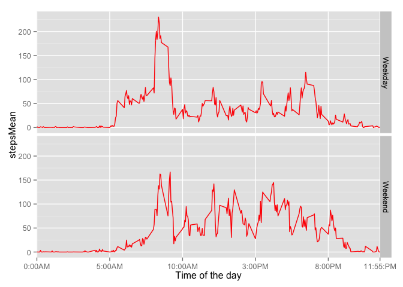

```r
library(plyr)
totesDades$date <- as.Date(totesDades$date, "%Y-%m-%d")
grWeekend<-c("Saturday", "Sunday")
totesDades$Weekday <- with(totesDades, ifelse( weekdays(totesDades$date) %in% grWeekend, "Weekend", "Weekday"))

totesDades <- ddply(totesDades,  c("interval", "Weekday"), summarize, stepsMean=mean(steps))

ggplot(data = totesDades, aes(x = interval, y = stepsMean))  +
    geom_line(color = "red") + facet_grid(Weekday ~ .) +  xlab("Time of the day") +
    scale_x_discrete(breaks = c("0","500","1000","1500","2000","2355"), labels=c("0:00AM", "5:00AM", "10:00AM", "3:00PM", "8:00PM","11:55:PM"))
```